### Human Activity Recognition

Hossein Parsa

#### Introduction

Human Activity Recognition has traditionally been researched with focus on predicting the time that activities were performed. Another approach is to investigate how well an activity was performed[^1]. Recently collecting this data has become easy due to development and popularity of wearable devices.

#### Getting Data and Processing

```r
library(caret)
library(ggplot2)
set.seed(0)
fullSet<-read.csv("pml-training.csv", na.string=c("", "NA", "#DIV/0!"))

inTrain <- createDataPartition(y=fullSet$classe, p=0.7, list=FALSE)
data<-fullSet[inTrain,]
testData<-fullSet[-inTrain,]
```

A summary of data shows that some of the features are missing large number of values. Because of low variability in those features, we remove them from The data set and training process.

```r
drops<-c()
for (i in 1:dim(data)[2]) if (mean(is.na(data[,i]))>.5) drops <- c(drops, names(data)[i])
drops <- c(drops, "new_window")
data<-data[, !(colnames(data) %in% drops)]
data<-data[,6:59]
dim(data)
```

```
## [1] 13737    54
```

Checking for near zero variation among the rest of the features.

```r
nearZeroVar(data)
```

```
## integer(0)
```

```r
sum(complete.cases(data))
```

```
## [1] 13737
```

Checking correlation between features.

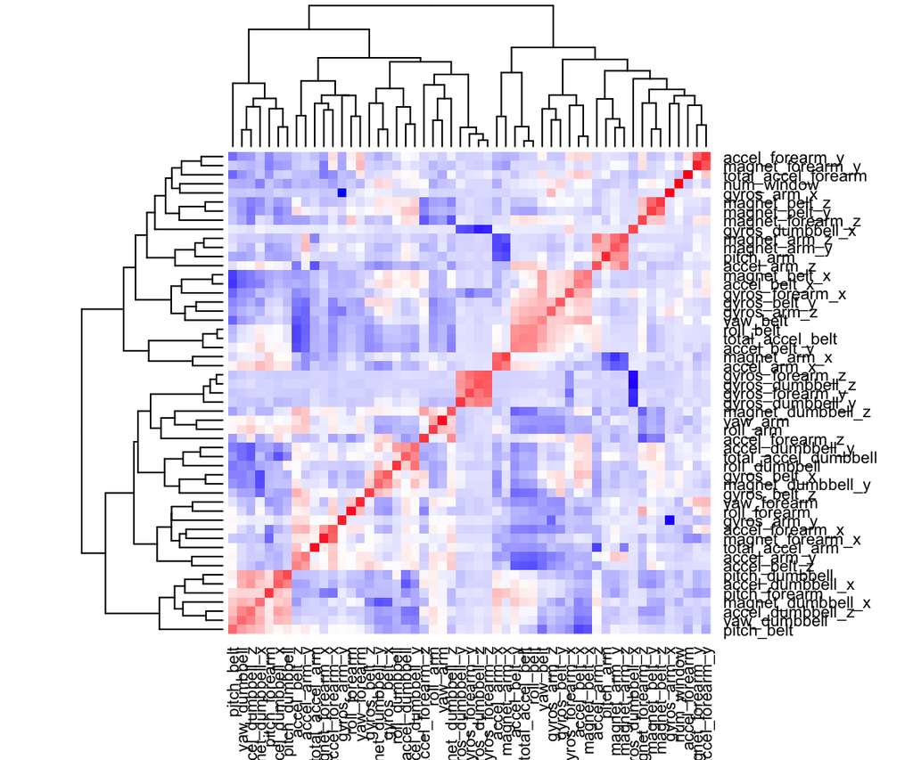

```r
Corr <- cor(data[, names(data) != "classe"])
mcol <- colorRampPalette(c("blue", "white", "red"))(n = 200)
heatmap(Corr, col = mcol)
```

#### Training

For building the prediction model and training, we use `Gradient Boosting Method` or GBM. We also use `repeated 2-fold cross validation` to reduce the `out of sample error` i.e. to reduce the error when the model is applied to a new data set. Preprocessing methods `center` and `scale` are also included in the training function to normalize the features’ data.

```r
gbmGrid <-  expand.grid(interaction.depth = c(1, 5, 9),
                        n.trees = (1:30)*50,
                        shrinkage = 0.1)

fitControl <- trainControl(## 2-fold CV,
  method = "repeatedcv",
  number = 2,
  ## repeated 2 times
  repeats = 2,
  allowParallel = TRUE,
  classProbs = TRUE)

gbmFit <- train(classe ~ ., data = data,
                 method = "gbm",
                 trControl = fitControl,
                 preProc = c("center", "scale"),
                 metric = c("ROC","Kappa"),
                 tuneGrid = gbmGrid,
                 verbose = F)
```

#### Cross Validation Acuracy

The following graph provides `in-sample` accuracy with respect to `Max Tree Depth` and `Boosting Iterations` based on 2-fold cross validation.

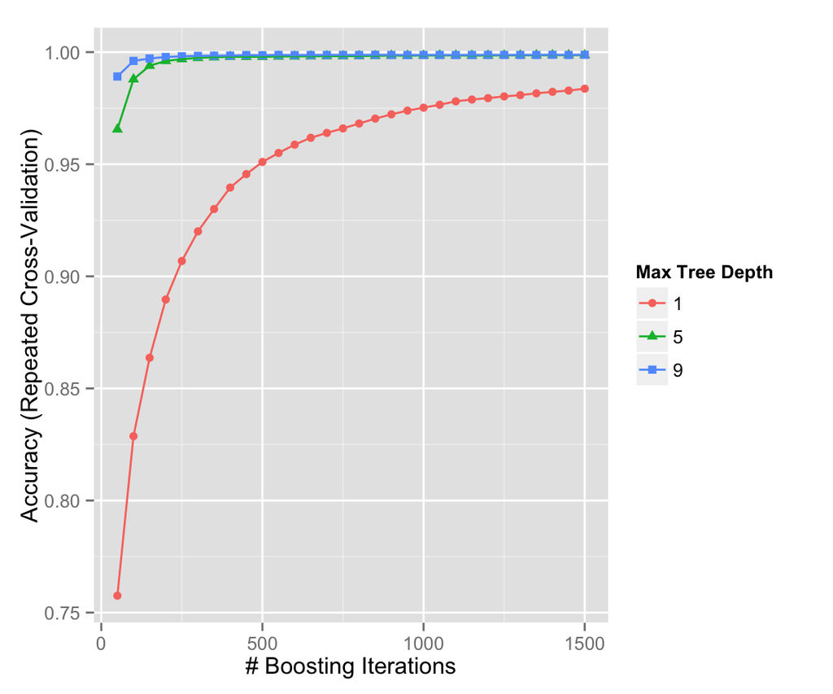

```r
ggplot(gbmFit)
```

#### Predicting

Predicting the test data set and evaluating the performance of learning process on this data set also Provides out of sample accuracy.

```r
Pred <- predict(gbmFit, newdata = testData)
confusionMatrix(Pred, testData$classe)
```

```
## Confusion Matrix and Statistics
##
##           Reference
## Prediction    A    B    C    D    E
##          A 1674    1    0    0    0
##          B    0 1138    0    0    0
##          C    0    0 1026    0    0
##          D    0    0    0  963    0
##          E    0    0    0    1 1082
##
## Overall Statistics
##
##                Accuracy : 0.9997
##                  95% CI : (0.9988, 1)
##     No Information Rate : 0.2845
##     P-Value [Acc > NIR] : < 2.2e-16
##
##                   Kappa : 0.9996
##  Mcnemar's Test P-Value : NA
##
## Statistics by Class:
##
##                      Class: A Class: B Class: C Class: D Class: E
## Sensitivity            1.0000   0.9991   1.0000   0.9990   1.0000
## Specificity            0.9998   1.0000   1.0000   1.0000   0.9998
## Pos Pred Value         0.9994   1.0000   1.0000   1.0000   0.9991
## Neg Pred Value         1.0000   0.9998   1.0000   0.9998   1.0000
## Prevalence             0.2845   0.1935   0.1743   0.1638   0.1839
## Detection Rate         0.2845   0.1934   0.1743   0.1636   0.1839
## Detection Prevalence   0.2846   0.1934   0.1743   0.1636   0.1840
## Balanced Accuracy      0.9999   0.9996   1.0000   0.9995   0.9999
```

As presented by the output of confusionMatrix function, the accuracy is 99.97%. So the `out-of-sample error` is estimated to be 0.03%.

Now applying the model to the unseen test set we get the following result.

```r
testSet<-read.csv("pml-testing.csv", na.string=c("", "NA", "#DIV/0!"))
predict(gbmFit, newdata = testSet)
```

```
##  [1] B A B A A E D B A A B C B A E E A B B B
## Levels: A B C D E
```

[^1]: http://groupware.les.inf.puc-rio.br/har.